# Lab1

##Assignment

Fine particulate matter (PM2.5) is an ambient air pollutant for which there is strong evidence that it is harmful to human health. In the United States, the Environmental Protection Agency (EPA) is tasked with setting national ambient air quality standards for fine PM and for tracking the emissions of this pollutant into the atmosphere. Approximatly every 3 years, the EPA releases its database on emissions of PM2.5. This database is known as the National Emissions Inventory (NEI). You can read more information about the NEI at the EPA National Emissions Inventory web site.

For each year and for each type of PM source, the NEI records how many tons of PM2.5 were emitted from that source over the course of the entire year. The data that you will use for this assignment are for 1999, 2002, 2005, and 2008.

```r
NEI <- readRDS("./summarySCC_PM25.rds")
SCC <- readRDS("./Source_Classification_Code.rds")
str(NEI)
```

```
## 'data.frame':    6497651 obs. of  6 variables:
##  $ fips     : chr  "09001" "09001" "09001" "09001" ...
##  $ SCC      : chr  "10100401" "10100404" "10100501" "10200401" ...
##  $ Pollutant: chr  "PM25-PRI" "PM25-PRI" "PM25-PRI" "PM25-PRI" ...
##  $ Emissions: num  15.714 234.178 0.128 2.036 0.388 ...
##  $ type     : chr  "POINT" "POINT" "POINT" "POINT" ...
##  $ year     : int  1999 1999 1999 1999 1999 1999 1999 1999 1999 1999 ...
```

```r
str(SCC)
```

```
## 'data.frame':    11717 obs. of  15 variables:
##  $ SCC                : Factor w/ 11717 levels "10100101","10100102",..: 1 2 3 4 5 6 7 8 9 10 ...
##  $ Data.Category      : Factor w/ 6 levels "Biogenic","Event",..: 6 6 6 6 6 6 6 6 6 6 ...
##  $ Short.Name         : Factor w/ 11238 levels "","2,4-D Salts and Esters Prod /Process Vents, 2,4-D Recovery: Filtration",..: 3283 3284 3293 3291 3290 3294 3295 3296 3292 3289 ...
##  $ EI.Sector          : Factor w/ 59 levels "Agriculture - Crops & Livestock Dust",..: 18 18 18 18 18 18 18 18 18 18 ...
##  $ Option.Group       : Factor w/ 25 levels "","C/I Kerosene",..: 1 1 1 1 1 1 1 1 1 1 ...
##  $ Option.Set         : Factor w/ 18 levels "","A","B","B1A",..: 1 1 1 1 1 1 1 1 1 1 ...
##  $ SCC.Level.One      : Factor w/ 17 levels "Brick Kilns",..: 3 3 3 3 3 3 3 3 3 3 ...
##  $ SCC.Level.Two      : Factor w/ 146 levels "","Agricultural Chemicals Production",..: 32 32 32 32 32 32 32 32 32 32 ...
##  $ SCC.Level.Three    : Factor w/ 1061 levels "","100% Biosolids (e.g., sewage sludge, manure, mixtures of these matls)",..: 88 88 156 156 156 156 156 156 156 156 ...
##  $ SCC.Level.Four     : Factor w/ 6084 levels "","(NH4)2 SO4 Acid Bath System and Evaporator",..: 4455 5583 4466 4458 1341 5246 5584 5983 4461 776 ...
##  $ Map.To             : num  NA NA NA NA NA NA NA NA NA NA ...
##  $ Last.Inventory.Year: int  NA NA NA NA NA NA NA NA NA NA ...
##  $ Created_Date       : Factor w/ 57 levels "","1/27/2000 0:00:00",..: 1 1 1 1 1 1 1 1 1 1 ...
##  $ Revised_Date       : Factor w/ 44 levels "","1/27/2000 0:00:00",..: 1 1 1 1 1 1 1 1 1 1 ...
##  $ Usage.Notes        : Factor w/ 21 levels ""," ","includes bleaching towers, washer hoods, filtrate tanks, vacuum pump exhausts",..: 1 1 1 1 1 1 1 1 1 1 ...
```

1. Have total emissions from PM2.5 decreased in the United States from 1999 to 2008? Make a plot showing the **total** PM2.5 emission from all sources for each of the years 1999, 2002, 2005, and 2008.

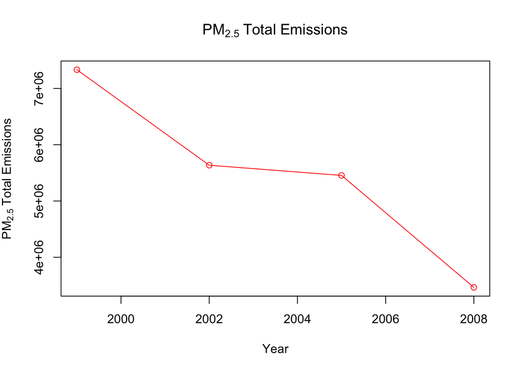

```r
dynNEI <- aggregate(Emissions ~ year, NEI, sum)

plot(dynNEI$year,
     dynNEI$Emissions,
     type = "o",
     col = "red",
     main = expression(PM[2.5]~ "Total Emissions"),
     ylab = expression(PM[2.5] ~ "Total Emissions"),
     xlab = "Year")
```

2. Have total emissions from PM2.5 decreased in the **Baltimore City**, Maryland (`fips == "24510"`) from 1999 to 2008?

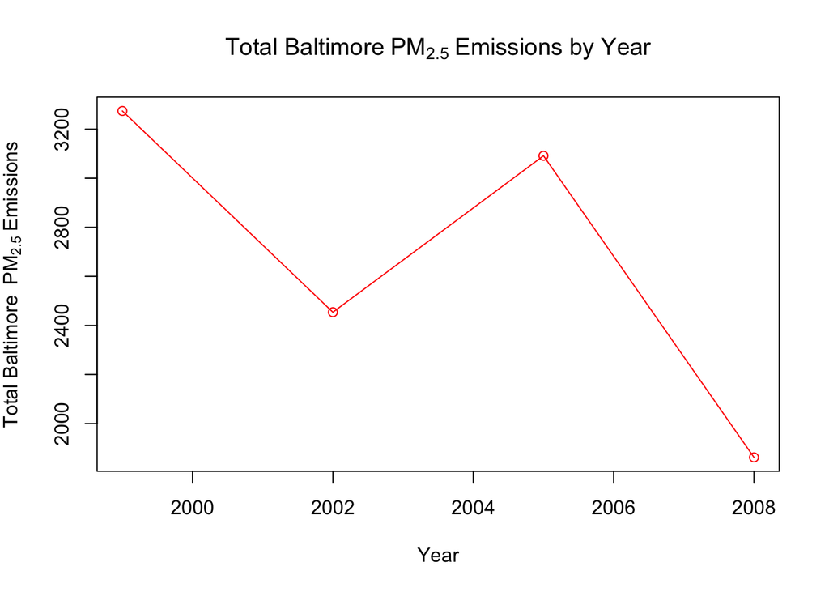

```r
baltimore <- subset(NEI, NEI$fips == "24510")
dynBaltimore <- aggregate(Emissions ~ year, baltimore, sum)
plot(dynBaltimore$year,
     dynBaltimore$Emissions,
     type = "o",
     main = expression("Total Baltimore" ~ PM[2.5] ~ "Emissions by Year"),
     xlab = "Year",
     ylab = expression("Total Baltimore "~ PM[2.5] ~ "Emissions"),
     col = "red")
```

3. Of the four types of sources indicated by the `type` (point, nonpoint, onroad, nonroad) variable, which of these four sources have seen decreases in emissions from 1999–2008 for **Baltimore City**? Which have seen increases in emissions from 1999–2008?

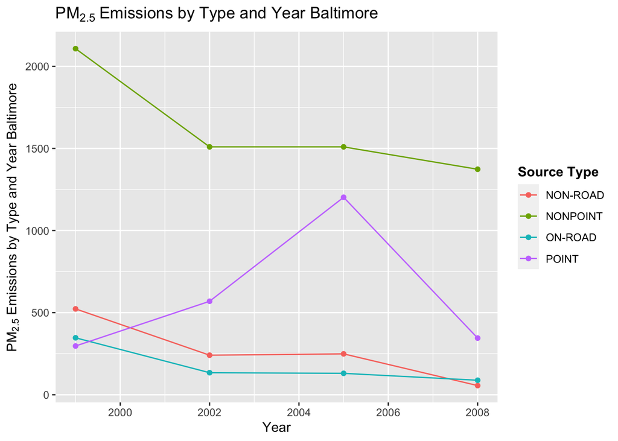

```r
library(ggplot2)
library(ggExtra)
baltimore <- subset(NEI, NEI$fips == "24510")
baltimoreType <- aggregate(Emissions ~ year + type, baltimore, sum)

ggplot(baltimoreType,
      aes(year, Emissions, col = type)) +
      geom_line() +
      geom_point() +
      ggtitle(expression(PM[2.5] ~ "Emissions by Type and Year Baltimore")) +
      ylab(expression(PM[2.5] ~ "Emissions by Type and Year Baltimore")) +
      xlab("Year") +
      scale_colour_discrete(name = "Source Type") +
      theme(legend.title = element_text(face = "bold"))
```

4. Across the United States, how have emissions from coal combustion-related sources changed from 1999–2008?

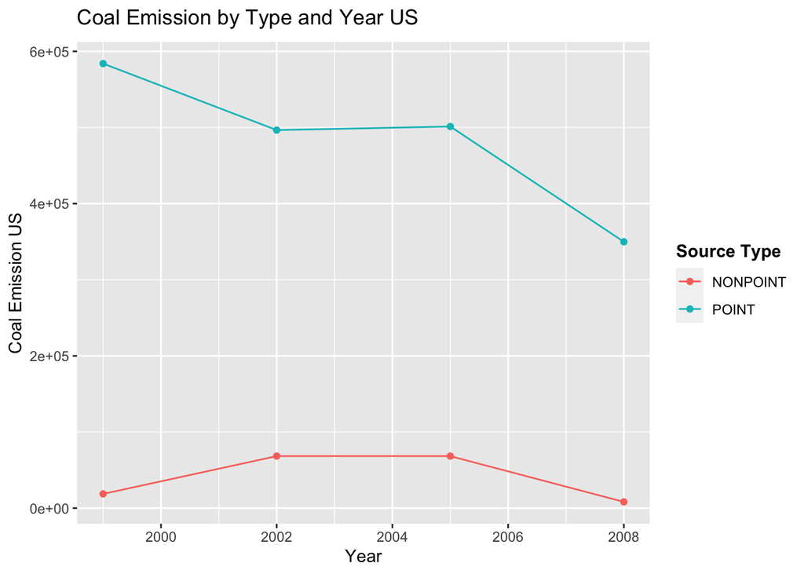

```r
SCCcoal <- SCC[grepl("coal", SCC$Short.Name, ignore.case = T),]
NEIcoal <- NEI[NEI$SCC %in% SCCcoal$SCC,]
dynCoal <- aggregate(Emissions ~ year + type, NEIcoal, sum)

ggplot(dynCoal, aes(year, Emissions, col = type)) +
      geom_line() +
      geom_point() +
      ggtitle(expression("Coal Emission by Type and Year US")) +
      xlab("Year") +
      ylab(expression("Coal Emission US")) +
      scale_colour_discrete(name = "Source Type") +
      theme(legend.title = element_text(face = "bold"))
```

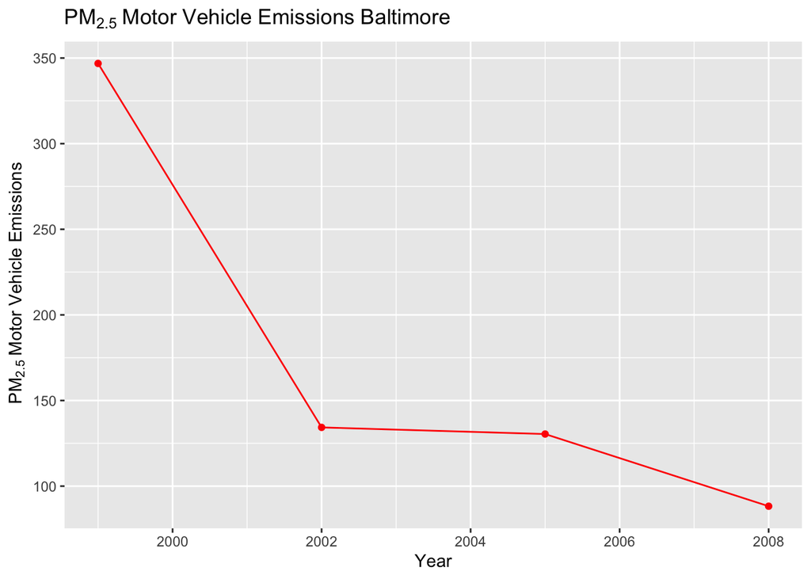

```r
baltimore <- subset(NEI, NEI$fips == "24510" & NEI$type == "ON-ROAD")
baltimoreM <- aggregate(Emissions ~ year, baltimore, sum)

ggplot(baltimoreM, aes(year, Emissions)) +
      geom_line(col = "red") +
      geom_point(col = "red") +
      ggtitle(expression(PM[2.5] ~ "Motor Vehicle Emissions Baltimore")) +
      xlab("Year") +
      ylab(expression(~PM[2.5]~ "Motor Vehicle Emissions"))
```

6. Compare emissions from motor vehicle sources in Baltimore City with emissions from motor vehicle sources in **Los Angeles County**, California (`fips == "06037"`). Which city has seen greater changes over time in motor vehicle emissions?

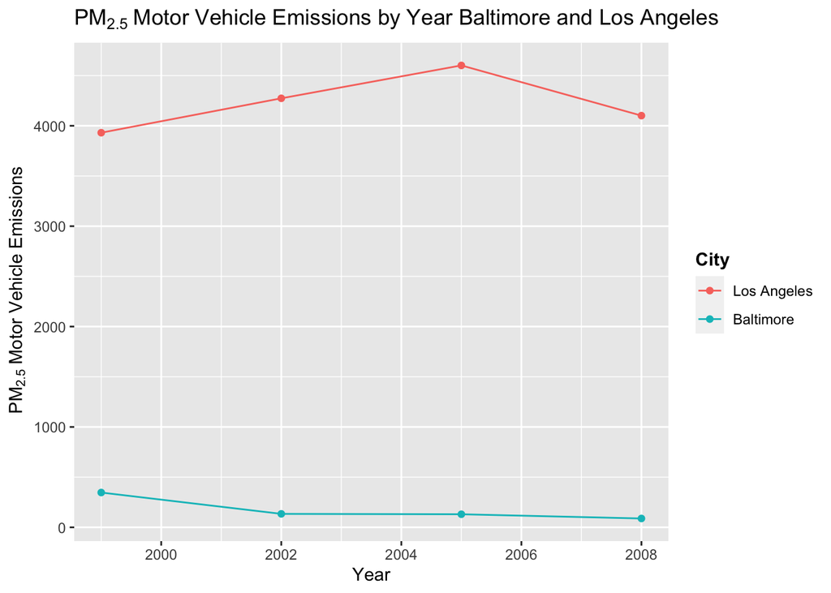

```r
balt_vs_los <- subset(NEI, NEI$fips %in% c("24510","06037") & NEI$type == "ON-ROAD")
balt_vs_los2 <- aggregate(Emissions ~ year + fips, balt_vs_los, sum)

ggplot(balt_vs_los2, aes(year, Emissions, col = fips)) +
      geom_line() +
      geom_point() +
      ggtitle(expression(PM[2.5] ~ "Motor Vehicle Emissions by Year Baltimore and Los Angeles")) +
      labs(x = "Year", y = expression(~PM[2.5]~ "Motor Vehicle Emissions") ) +
      scale_colour_discrete(name = "City", labels = c("Los Angeles", "Baltimore")) +
      theme(legend.title = element_text(face = "bold"))
```